# Reproducible Research Project 1

We will first load our activity dataset and relevant packages

```r
activity <- read.csv("activity.csv")
library(ggplot2)
library(dplyr)
```

transform the date column into class date

```r
dates <- as.Date(activity$date, "%Y-%m-%d")
activity$date <- dates
```

aggregate steps based on date plot histogram of total steps per day report mean and median of total steps per day remove missing values for these calculations

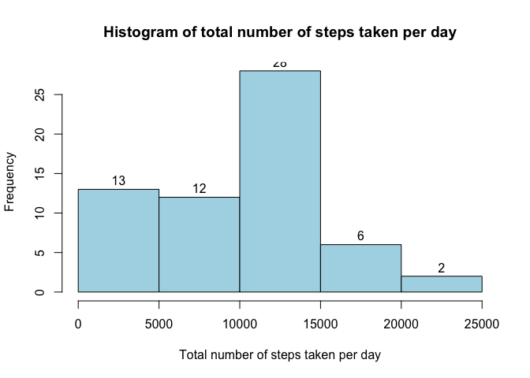

```r
agg <- aggregate(activity$steps, by = list(activity$date), sum, na.rm = TRUE,
                 na.action = NULL)
hist(agg$x, col = "lightblue", xlab = "Total number of steps taken per day",
     main = "Histogram of total number of steps taken per day", labels = TRUE)
```

```r
mean(agg$x, na.rm = TRUE)
```

```
## [1] 9354.23
```

```r
median(agg$x, na.rm = TRUE)
```

```
## [1] 10395
```

aggregate steps based on interval remove missing values plot time series plot of average daily steps output the 5-min interval with the highest average daily number of steps

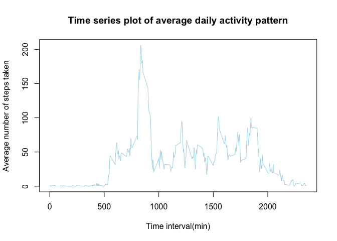

```r
agg_interval <- aggregate(activity$steps, by = list(activity$interval), mean,
                          na.rm = TRUE, na.action=NULL)
plot(agg_interval$Group.1, agg_interval$x, type = "l",
     main = "Time series plot of average daily activity pattern",
     xlab = "Time interval(min)",
     ylab = "Average number of steps taken", col = "lightblue")
```

```r
agg_interval$Group.1[which.max(agg_interval$x)] #the 5-min interval with the highest average daily number of steps
```

```
## [1] 835
```

calculate and report the total number of missing values in the dataset Strategy: impute missing values with average of that interval across all days this is done with the for loop the dataset “act” returned by this for loop has all the missing values imputed

report the mean and median of the avg total number of steps per day after imputation

both the mean and median changed after imputing the missing values the mean changed from 9354.23 to 10766.19 the median after imputation is equal to the mean (10766.19), it was originally 10395

```r
sum(is.na(activity$steps)) #total number of missing values in the dataset
```

```
## [1] 2304
```

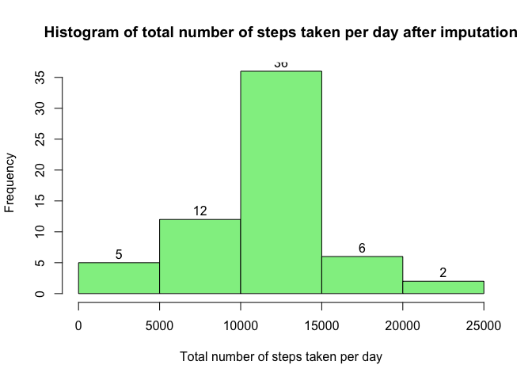

```r
na_in <- which(is.na(activity$steps)) #get NA value indices
act <- activity #replicate the data frame
for (i in na_in) {
    act$steps[i] <- agg_interval$x[which(agg_interval$Group.1 == act$interval[i])]
}

agg_na_imputed <- aggregate(act$steps, by = list(act$date), sum)
hist(agg_na_imputed$x, col = "lightgreen",
     xlab = "Total number of steps taken per day",
     main = "Histogram of total number of steps taken per day after imputation",
     labels = TRUE)
```

```r
mean(agg_na_imputed$x)
```

```
## [1] 10766.19
```

```r
median(agg_na_imputed$x)
```

```
## [1] 10766.19
```

Get the day of the week from the date column of the dataset add a column to the dataset – a factor variable indicating whether a date is weekday or weekend group by interval and weekday variables using group_by function from dplyr package get mean steps for each group with summarize function

make time series panel plot with qplot function of the ggplot2 system

```r
weekday <- weekdays(act$date)
weekdays <- c("Monday", "Tuesday", "Wednesday", "Thursday", "Friday")
weekday <- factor((weekday %in% weekdays), levels=c(FALSE, TRUE), labels=c('weekend', 'weekday'))

act <- cbind(act, weekday)

grouped <- group_by(act, interval, weekday)
summ <- summarize(grouped, mean = mean(steps))
```

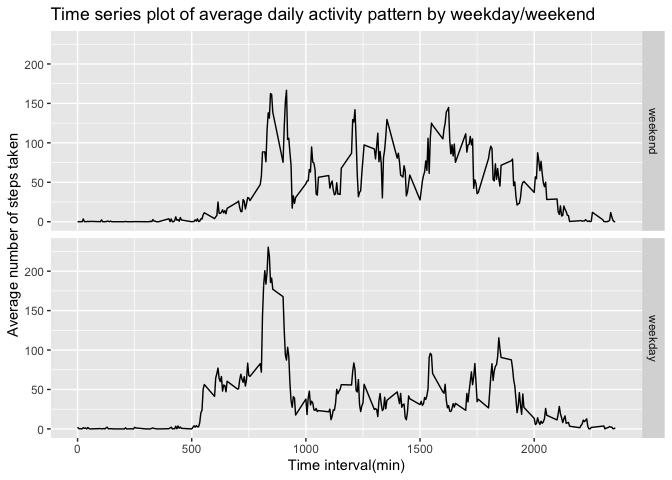

```r
qplot(interval, mean, data = summ, geom = "line", facets = weekday~.,
      xlab = "Time interval(min)", ylab = "Average number of steps taken",
      main = "Time series plot of average daily activity pattern by weekday/weekend")
```